# Modeling Notebook for ESRI Practicum

## Data Preparation

### Data Cleaning

These 3 functions are to clean up/modify the data. Water source is one of the most important feature in predicting the water point status. So, it is very important that we have a very clean water source column in our dataset.

There are 3 columns for the water source in our dataset -

- water_source_clean,
- water_tech_clean and
- water_source.

Water_source has the lowest number of null values but the description of the water sources is very long, misleading and repetitive. Water tech clean and water source clean both have good description of the water sources. We wanted to have the less number of categories for the water sources without losing any information as we will be creating the dummy variables for this columns for our algorithms.

- The first function tries to put the description of the water source from either water_tech_clean or water_source depending on which one is not null.
- The second function clubs the same description water source in one category. For example - Shadoof Sahduf, Shahduf..etc will all be placed under Shadoof.
- The third functions converts the categorized "yes"/"no" for the water point status into binary 1 and 0.

```python
def water_source_cleanup_1(row):
    if pd.isnull(row['F_water_source_clean']):
        if pd.isnull(row['F_water_tech_clean']):
            return row['F_water_source']
        else:
            return row["F_water_tech_clean"]
    else:
        return row['F_water_source_clean']

def water_source_cleanup_2(row):
    if pd.isnull(row["water_source_sup_clean"]):
        return np.nan
    elif ("well" in row['water_source_sup_clean']) or ("Well" in row['water_source_sup_clean']):
        return "Water Well"
    elif row['water_source_sup_clean'].startswith("Shad"):
        return "Shadoof"
    elif "Spring" in row['water_source_sup_clean']:
        return "Spring"
    else:
        return row["water_source_sup_clean"]

def label_wp_status(row):
    if pd.isnull(row['F_status_id']):
        return np.nan
    if row['F_status_id'] == "Yes":
        return int(1)
    if row['F_status_id'] == "No":
        return int(0)
```

```python
# Call to the above functions to clean up and creates new columns for the water source and for the wp status
wp_ml_df['water_source_sup_clean'] = wp_ml_df.apply (lambda row: water_source_cleanup_1(row), axis=1)
wp_ml_df['water_source_sup_clean'] = wp_ml_df.apply(lambda row: water_source_cleanup_2(row), axis=1)
wp_ml_df['wp_status_label'] = wp_ml_df.apply (lambda row: label_wp_status(row), axis=1)
```

Dropping the 3 water source columns as we do not need them now because we already have created a new super clean water source column with the help of above functions.

```python
wp_ml_df.drop(columns=["F_water_source","F_water_source_clean","F_water_tech_clean"], inplace=True)
```

```python
wp_ml_df.isna().sum()
```

```
F_status_id                   0
F_install_year            15225
management_clean          11857
Population_1000m              0
water_source_sup_clean      101
wp_status_label            3100
dtype: int64
```

```python
print(f"There are {len(wp_ml_df)} rows before the Nan drop")
wp_ml_df.dropna(axis="index", how="any",inplace=True)
print(f"There are {len(wp_ml_df)} rows after the Nan drop")
```

```
There are 118110 rows before the Nan drop
There are 99455 rows after the Nan drop
```

Determing the age of the water point by subtracting the install year from the current year and dropping the status id and install year columns.

```python
wp_ml_df["F_install_year"] = wp_ml_df["F_install_year"].astype(int)
wp_ml_df["wp_Age"] = 2021 - wp_ml_df["F_install_year"]
wp_ml_df.drop(columns=["F_status_id","F_install_year"], inplace=True)
```

```python
wp_ml_df["wp_status_label"] = wp_ml_df["wp_status_label"].astype(int)
wp_ml_df.head()
```

|  | management_clean | Population_1000m | water_source_sup_clean | wp_status_label | wp_Age |
| --- | --- | --- | --- | --- | --- |
| 0 | Other | 588 | Borehole | 1 | 13 |
| 1 | Other | 0 | Borehole | 1 | 32 |
| 2 | Community Management | 4592 | Valley Tank | 1 | 7 |
| 4 | Other | 2920 | Tapstand | 1 | 16 |
| 5 | Community Management | 688 | Valley Tank | 1 | 18 |

### Dummy Variables

Creating dummy variables for the categorical columns.

```python
cols_for_encoding = ["water_source_sup_clean", "management_clean"]
wp_ml_encoded_df = pd.get_dummies(data=wp_ml_df, columns=cols_for_encoding)
```

```python
wp_ml_encoded_df.head()
```

|  | Population_1000m | wp_status_label | wp_Age | water_source_sup_clean_Borehole | water_source_sup_clean_Kiosk | water_source_sup_clean_Mechanized Pump | water_source_sup_clean_Piped Water | water_source_sup_clean_Rainwater Harvesting | water_source_sup_clean_Spring | water_source_sup_clean_Surface Water (River/Stream/Lake/Pond/Dam) | water_source_sup_clean_Tapstand | water_source_sup_clean_Underground Pumped Water | water_source_sup_clean_Valley Tank | water_source_sup_clean_Water Well | management_clean_Community Management | management_clean_Direct Government Operation | management_clean_Other | management_clean_Other Institutional Management | management_clean_Private Operator/Delegated Management | management_clean_Private Person | management_clean_School Management |
| --- | --- | --- | --- | --- | --- | --- | --- | --- | --- | --- | --- | --- | --- | --- | --- | --- | --- | --- | --- | --- | --- |
| 0 | 588 | 1 | 13 | 1 | 0 | 0 | 0 | 0 | 0 | 0 | 0 | 0 | 0 | 0 | 0 | 0 | 1 | 0 | 0 | 0 | 0 |
| 1 | 0 | 1 | 32 | 1 | 0 | 0 | 0 | 0 | 0 | 0 | 0 | 0 | 0 | 0 | 0 | 0 | 1 | 0 | 0 | 0 | 0 |
| 2 | 4592 | 1 | 7 | 0 | 0 | 0 | 0 | 0 | 0 | 0 | 0 | 0 | 1 | 0 | 1 | 0 | 0 | 0 | 0 | 0 | 0 |
| 4 | 2920 | 1 | 16 | 0 | 0 | 0 | 0 | 0 | 0 | 0 | 1 | 0 | 0 | 0 | 0 | 0 | 1 | 0 | 0 | 0 | 0 |
| 5 | 688 | 1 | 18 | 0 | 0 | 0 | 0 | 0 | 0 | 0 | 0 | 0 | 1 | 0 | 1 | 0 | 0 | 0 | 0 | 0 | 0 |

## Data Visualization and Analysis for Modeling purpose

Below bar plot shows that we have an un-balanced class labels.

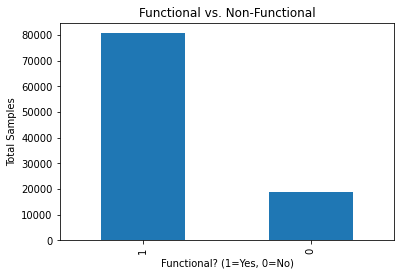

```python
wp_ml_encoded_df["wp_status_label"].value_counts().plot(kind='bar')
plt.title('Functional vs. Non-Functional')
plt.xlabel('Functional? (1=Yes, 0=No)')
plt.ylabel('Total Samples')
plt.show()
```

### Check what percentage are functional and non functional

```python
functional_wp = wp_ml_encoded_df["wp_status_label"].value_counts().iloc[0]
non_functional_wp = wp_ml_encoded_df["wp_status_label"].value_counts().iloc[1]
total_wp = len(wp_ml_encoded_df["wp_status_label"])

functional_percent = (functional_wp/total_wp)*100
non_functional_percent = (non_functional_wp/total_wp)*100

print(f"There are {round(functional_percent,2)} % water points that are functional in our dataset.")
print(f"There are {round(non_functional_percent,2)} % water points that are non-functional in our dataset.")
```

```
There are 81.09 % water points that are functional in our dataset.
There are 18.91 % water points that are non-functional in our dataset.
```

## Oversampling using SMOTE technique to balance the dataset

### Resampling for imbalanced classes

The **highly skewed nature** of this data presents a challenge in training a classifier. With such a small percent of minority samples, the majority samples will heavily weight the training data, and the final model will be likely to predict that any new sample is Functional.

The idea behind **SMOTE** is that in order to train a model that can accurately identify the minority class, you need a reasonably balanced training set. At a high level, SMOTE is used to generate new instances of the minority class using a set of similar, but not identical, minority samples from the training set. A minority sample is chosen at random, and then a new sample is generated using a linear combination of the k-nearest neighbors of the randomly chosen sample. Other resampling techniques merely duplicate some samples from the training set, but this does not add any new information to help fit a model to the patterns in the data. With SMOTE, the new samples are not merely copies of the training data, so they can add to the predictive power of the model in testing.

```python
# find proportion of minority sample in data
def get_minority_proportion(y_vals):
    unique, counts = np.unique(y_vals, return_counts=True)
    cts_dict = dict(zip(unique, counts))
    majority_counts = cts_dict[0]
    minority_counts = cts_dict[1]
    minority_prop = minority_counts/(minority_counts+majority_counts)
    return minority_prop, minority_counts

# use SMOTE For oversampling minority class
def get_oversample(X, y):
    from imblearn.over_sampling import SMOTE
    sm = SMOTE()
    X_over, y_over = sm.fit_resample(X, y)
    minority_prop, _ = get_minority_proportion(y_over)
#     print(f'minority proportion in oversampled data: {minority_prop*100:0.2f}%')
    return X_over, y_over

# standardize data
def scale_data(X):
    from sklearn.preprocessing import StandardScaler
    scaler = StandardScaler().fit(X)
    return scaler.transform(X)
```

## Correlation Matrix to help selecting the features

We are checking the feature's correlation values, which measures the degree of linear relationship between each pair of variables.

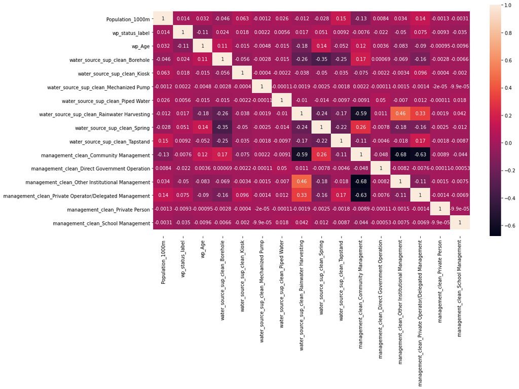

```python
corr_mtx = wp_ml_encoded_df[['Population_1000m', 'wp_status_label', 'wp_Age',
       'water_source_sup_clean_Borehole', 'water_source_sup_clean_Kiosk',
       'water_source_sup_clean_Mechanized Pump',
       'water_source_sup_clean_Piped Water',
       'water_source_sup_clean_Rainwater Harvesting',
       'water_source_sup_clean_Spring',
       'water_source_sup_clean_Tapstand',
       'management_clean_Community Management',
       'management_clean_Direct Government Operation',
       'management_clean_Other Institutional Management',
       'management_clean_Private Operator/Delegated Management',
       'management_clean_Private Person',
       'management_clean_School Management']].corr()
ax = sns.heatmap(corr_mtx, annot=True)
bottom, top = ax.get_ylim()
ax.set_ylim(bottom + 0.5, top - 0.5)
fig = plt.gcf()
fig.set_size_inches(15,9)
plt.show()
```

# Define Evaluation Matrix

Thus, with our analysis, we needed an evaluation metric that balances recall with precision. F1 score is often used to achieve this balance, and we decided to use a variation on F1 score: the F-beta score. With this metric, a  parameter is added to weight precision and recall depending on the needs of the model.

The formula for F-beta is:

**F-beta = ((1 +  $\beta^2$) * Precision * Recall) / ( $\beta^2$ * Precision + Recall)**

We set $\beta$ = 2, because recall should hold greater weight than precision.

This metric is known as the **F2 score**.

```python
# f2 score: 2X emphasis on recall, vs precision (minimize false negatives)
def get_f_beta_score(precision, recall, beta=0):
    f_beta_score = ((1 + beta ** 2) * precision * recall) / (beta ** 2 * precision + recall)
    return f_beta_score


# function to evaluate model performance on testing data
def get_eval_metrics(clf_name, ytrue, ypreds):
    accy = accuracy_score(ytrue, ypreds)
    conf_mtx = confusion_matrix(ytrue, ypreds)
    recall = np.diag(conf_mtx) / np.sum(conf_mtx, axis=1)
    precision = np.diag(conf_mtx) / np.sum(conf_mtx, axis=0)
    f1_score = 2*((precision*recall)/(precision+recall))
    f2_score = get_f_beta_score(precision, recall, beta=2)
    auc = roc_auc_score(ytrue, ypreds)
    metrics = {'conf_mtx': conf_mtx,
               'accuracy': accy,
               'auc': auc,
               'recall': recall,
               'precision': precision,
               'f1_score': f1_score,
               'f2_score': f2_score}
    return metrics
```

# Split data into train and test set

```python
# split data
feature_labels = [col for col in wp_ml_encoded_df.drop('wp_status_label', axis=1)]
X = wp_ml_encoded_df.drop('wp_status_label', axis=1).values
y = wp_ml_encoded_df['wp_status_label'].values
X_train, X_test, y_train, y_test = train_test_split(X, y, random_state=42)
```

## Creating X train and y train using the oversampling

```python
X_train_over, y_train_over = get_oversample(X_train, y_train)
```

## Balanced class labels plot after oversampling the data

As shown below, after oversampling the data is looking good.

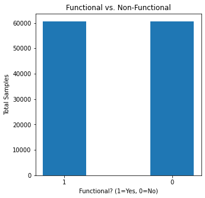

```python
func_wp_over = np.count_nonzero(y_train_over == 1)
nonfunc_wp_over = np.count_nonzero(y_train_over == 0)
wp_status = ["1", "0"]
wp_val = [func_wp_over, nonfunc_wp_over]

fig = plt.figure(figsize = (5, 5))

plt.bar(wp_status, wp_val, width=0.4)

plt.title('Functional vs. Non-Functional')
plt.xlabel('Functional? (1=Yes, 0=No)')
plt.ylabel('Total Samples')
plt.show()
```

## Function to visualize the dataset in 2D

Used Principal Component Analysis (PCA) to reduce the dimension of the dataset from 20 features to 2 components to visualize the data.

The **second plot** shows that, although the classes are still not easily separable, there are more minority samples, so in theory a model will be better able to learn the patterns that exist and identify minority samples more effectively.

We recognize that these plots highlight the potential outliers in this dataset. We did check for outliers during EDA, and we tested all models on data with the outliers' values clipped using the first and third quartiles and interquartile range. However, this actually worsened model performance, so we left the outliers alone.

We experimented with simpler methods for dealing with imbalanced classes, such as setting the class weight parameter in a Logistic Regression model to "balanced," or tuning the scale pos weight parameter in an XGBoost model. The better results, however, came from using **Synthetic Minority Oversampling Technique (SMOTE).**

```python
# visualize data in 2D
def show_2D_scatterplot(X, y, title='Data in 2 Dimensions', n_components=2):
    pca = PCA(n_components=n_components)
    X_new = pca.fit_transform(X)
    fig = plt.figure(figsize=(8,8))
    if n_components == 2:
        plt.scatter(X_new[:,0], X_new[:,1], c=y)
        plt.title(title)
        plt.xlabel('PC1')
        plt.ylabel('PC2')
        plt.show()
    else:
        ax = plt.axes(projection='3d')
        ax.scatter3D(X_new[:,0],X_new[:,1],X_new[:,2] , c=Y)
        plt.show()
```

### Plot for the data without the oversampling in 2D

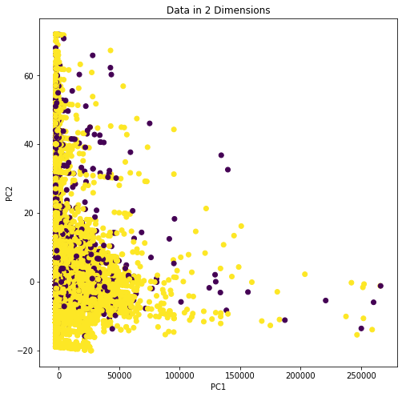

```python
show_2D_scatterplot(X_train, y_train, title='Data in 2 Dimensions', n_components=2)
```

### Plot for the data with the oversampling in 2D

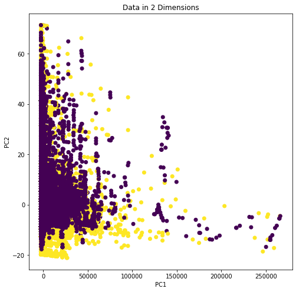

```python
show_2D_scatterplot(X_train_over, y_train_over, title='Data in 2 Dimensions', n_components=2)
```

# Hyperparameter Tuning and Modeling

We used 5 different machine learning models with and without oversampling dataset to create a classification model that can predict if the waterpoint is functional or non-functional. At the end, we had 10 models to compare. We are comparing model’s different matrices as well as time taken to finish the prediction on the test dataset.

1. XGBoost,
2. Logistic Regression,
3. Naive Bayes,
4. KNN.
5. Random Forest

**The model that outperformed is :**

- n estimators: 200
- max depth: 5
- learning rate: 0.3

We expected the XGBoost Classifier to outperform the other modeling techniques, given its proven ability to identify non-linear patterns and classify minority samples accurately, even in highly skewed data such as ours.

One primary benefit of using a model like XGBoost is that there is

- no need to scale the data,
- perform feature selection, or
- reduce dimensionality before training the model.

Although we cleaned the data before model fitting, XGBoost can also perform well when outliers are present and when missing values are included.

The consistent performance of XGBoost is due to the non-linear nature of this classifier and the regularization parameters (both L1 and L2) included in its objective function, which minimize overfitting. Regularization, gradient boosting, tree pruning, and built-in cross-validation, are some of the features that give XGBoost an edge over other classification methods, such as Random Forest and AdaBoost.

**Other Model Results:**

When SMOTE was used to balance the data, the impact of overfitting was somewhat lessened. The models had more information to learn from in training and could therefore identify non-functional samples more effectively during testing. The overall performance was still not great, but SMOTE did make a difference.

```python
# functions for fitting model

## IF YOU ARE RUNNING THIS NB ON ARCCGIS PRO, PLEASE REMOVE THE n_jobs PARM AS IT WILL CAUSE MULTIPLE ARCCGIS PRO
## SESSIONS DUE TO THE BUG IN THE PRO. THIS HAS BEEN REPORTED TO ESRI.

def tune_hyperparameters(base_model, grid, X, y, scoring='auc'):

    print('***** Tuning Hyperparameters *****')
    random_model = GridSearchCV(estimator=base_model, param_grid=grid,scoring=scoring, cv=3, n_jobs=-1)
#     random_model = RandomizedSearchCV(estimator=base_model, param_distributions=grid, scoring=scoring,
#                                       random_state=30, n_iter=10, cv=3, n_jobs=-1)
    random_model.fit(X, y)
    return random_model.best_params_, random_model.best_score_

def fit_xgb(X, y, scoring='accuracy'):
    xgb_n_estimators = [100, 200, 500, 800]
    xgb_max_depth = [2, 5, 8]
#     xgb_min_child_weight = [1, 5, 9]
    xgb_eta = [0.1, 0.3, 0.4]
#     xgb_gamma = [0, 1, 4]

    xgb_grid = {'n_estimators': xgb_n_estimators,
                'max_depth': xgb_max_depth,
#                 'min_child_weight': xgb_min_child_weight,
                'eta': xgb_eta
#                 'gamma': xgb_gamma
               }

    spw = y[y==0].shape[0] / y[y==1].shape[0] # set weight to total_neg / total_pos
    base_model = XGBClassifier(objective='binary:logistic', eval_metric='aucpr', scale_pos_weight=spw)
    best_params, best_score = tune_hyperparameters(base_model, xgb_grid, X, y, scoring=scoring)
    print(f'best params for xgb: {best_params}\n')
    final_model = XGBClassifier(**best_params).fit(X, y)
    return final_model

def fit_lr(X, y, scoring='accuracy'):
    lr_solver = ['newton-cg', 'lbfgs', 'liblinear']
    lr_penalty = ['none', 'l1', 'l2', 'elasticnet']
    lr_C = [0.001,0.01,0.1,1,10,100]

    lr_grid = {'solver': lr_solver,
               'penalty': lr_penalty,
               'C': lr_C
               }

    base_model = LogisticRegression()
    best_params, best_score = tune_hyperparameters(base_model, lr_grid, X, y, scoring=scoring)
    print(best_params)
    final_model = LogisticRegression(**best_params).fit(X, y)
    return final_model

def fit_nb(X, y, scoring='accuracy'):
    nb_grid = {'var_smoothing': [1e-09, 2e-09]
          }
    base_model = GaussianNB()
    best_params, best_score = tune_hyperparameters(base_model, nb_grid, X, y, scoring=scoring)
    final_model = GaussianNB(**best_params).fit(X, y)
    return final_model

def fit_knn(X, y, scoring='accuracy'):
    knn_neighnors = [5,7,9,11,13,15]
    knn_weights = ['uniform','distance']
    knn_metric = ['minkowski','euclidean','manhattan']

    knn_grid = {'n_neighbors' : knn_neighnors,
                   'weights' : knn_weights,
                   'metric' : knn_metric
               }
    base_model = KNeighborsClassifier()
    best_params, best_score = tune_hyperparameters(base_model, knn_grid, X, y, scoring=scoring)
    final_model = KNeighborsClassifier(**best_params).fit(X, y)
    return final_model

def fit_rf(X, y, scoring='accuracy'):
    n_estimators = [100, 300, 500, 800, 1200]
    max_depth = [5, 8, 15, 25, 30]
    min_samples_split = [2, 5, 10, 15, 100]
    min_samples_leaf = [1, 2, 5, 10]

    rf_grid = {'n_estimators': n_estimators,
               'max_depth': max_depth,
                'min_samples_split':min_samples_split,
                'min_samples_leaf':min_samples_leaf
              }

    base_model = RandomForestClassifier()
    best_params, best_score = tune_hyperparameters(base_model, rf_grid, X, y, scoring=scoring)
    final_model = RandomForestClassifier(**best_params).fit(X, y)
    return final_model
```

## Main custom modeling function to put all the modeling steps together

```python
# function to put all steps together
def fit_predict_eval_model(X_train, X_test, y_train, y_test,
                                model='lr', scoring='auc',
                              resample=False, scale=False):

    if resample:
        print('***** Oversampling Data *****')
        X_train, y_train = get_oversample(X_train, y_train)

    if scale:
        print('***** Scaling Data *****')
        X_train = scale_data(X_train)
        X_test = scale_data(X_test)


    print('***** Fitting Model *****')
    if model == 'xgb':
        xgb = fit_xgb(X_train, y_train, scoring=scoring)
        print(f'xgb feature imps: {xgb.feature_importances_}')
        plt.bar(range(len(xgb.feature_importances_)), xgb.feature_importances_)
        plt.show()
        print('***** Getting XGB Predictions *****')
        y_train_preds = xgb.predict(X_train)
        y_test_preds = xgb.predict(X_test)

    elif model == 'lr':
        lr = fit_lr(X_train, y_train, scoring=scoring)
        print('***** Getting Logistic Regression Predictions *****')
        y_train_preds = lr.predict(X_train)
        y_test_preds = lr.predict(X_test)

    elif model == 'knn':
        knn = fit_knn(X_train, y_train, scoring=scoring)
        print('***** Getting KNN Predictions *****')
        y_train_preds = knn.predict(X_train)
        y_test_preds = knn.predict(X_test)

    elif model == 'nb':
        nb = fit_nb(X_train, y_train, scoring=scoring)
        print('***** Getting Naive Bayes Predictions *****')
        y_train_preds = nb.predict(X_train)
        y_test_preds = nb.predict(X_test)

    elif model == 'rf':
        rf = fit_rf(X_train, y_train, scoring=scoring)
        print('***** Getting Random Forest Predictions *****')
        y_train_preds = rf.predict(X_train)
        y_test_preds = rf.predict(X_test)

    print('***** Getting Performance Metrics *****')
    train_metrics = get_eval_metrics(model, y_train, y_train_preds)
    test_metrics = get_eval_metrics(model, y_test, y_test_preds)
    return train_metrics, test_metrics
```

## XGBoost model

### XGBoost with NO oversampling

```
***** Fitting Model *****
***** Tuning Hyperparameters *****
best params for xgb: {'eta': 0.4, 'max_depth': 8, 'n_estimators': 800}

[21:44:26] WARNING: C:/Users/Administrator/workspace/xgboost-win64_release_1.4.0/src/learner.cc:1095: Starting in XGBoost 1.3.0, the default evaluation metric used with the objective 'binary:logistic' was changed from 'error' to 'logloss'. Explicitly set eval_metric if you'd like to restore the old …
xgb feature imps: [0.0390939  0.0601492  0.04821851 0.03662249 0.         0.00995373
 0.08783591 0.05069974 0.0228509  0.05414776 0.         0.02182629
 0.13520445 0.05075866 0.04233252 0.05400212 0.11498131 0.08476896
 0.         0.08655363]
```

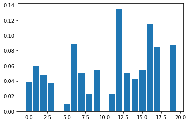

```
***** Getting XGB Predictions *****
***** Getting Performance Metrics *****
modeling took 593.7819445133209 seconds
*** training metrics for model=xgb ***
conf_mtx:
 [[ 4676  9316]
 [  548 60051]]
accuracy:
 0.8677588449008593
auc:
 0.6625739563753517
recall:
 [0.33419097 0.99095695]
precision:
 [0.89509954 0.86569983]
f1_score:
 [0.48667777 0.92410323]
f2_score:
 [0.38207609 0.96308735]

*** testing metrics for model=xgb ***
conf_mtx:
 [[  642  4168]
 [  875 19179]]
accuracy:
 0.797176640926641
auc:
 0.5449198701966229
recall:
 [0.13347193 0.95636781]
precision:
 [0.42320369 0.82147599]
f1_score:
 [0.20293978 0.88380452]
f2_score:
 [0.15464663 0.92595811]
```

```python
f2_scorer = make_scorer(fbeta_score, beta=2)
model = 'xgb'
start = time.time()
train_metrics, test_metrics = fit_predict_eval_model(X_train, X_test, y_train, y_test,
                                 model=model, scoring=f2_scorer)

end = time.time()
elapsed = end - start
print(f'modeling took {elapsed} seconds')
print(f'*** training metrics for model={model} ***')
for metric, val in train_metrics.items():
    print(f'{metric}:\n {val}')

print(f'\n*** testing metrics for model={model} ***')
for metric, val in test_metrics.items():
    print(f'{metric}:\n {val}')
```

### XGBoost with oversampling SMOTE

```
***** Oversampling Data *****
***** Fitting Model *****
***** Tuning Hyperparameters *****
best params for xgb: {'eta': 0.3, 'max_depth': 5, 'n_estimators': 200}

[22:52:32] WARNING: /Users/travis/build/dmlc/xgboost/src/learner.cc:1095: Starting in XGBoost 1.3.0, the default evaluation metric used with the objective 'binary:logistic' was changed from 'error' to 'logloss'. Explicitly set eval_metric if you'd like to restore the old behavior.
xgb feature imps: [0.01035689 0.0207116  0.10615312 0.03863043 0.         0.00941952
 0.10839822 0.1398754  0.02273182 0.1190863  0.         0.03130623
 0.07082196 0.03736145 0.00562866 0.06340996 0.10550096 0.10924523
 0.         0.00136233]
```

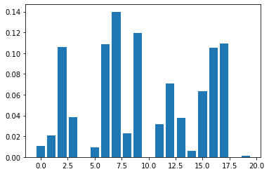

```
***** Getting XGB Predictions *****
***** Getting Performance Metrics *****
modeling took 2764.3142671585083 seconds
*** training metrics for model=xgb ***
conf_mtx:
 [[42706 17893]
 [11568 49031]]
accuracy:
 0.7569184309972111
auc:
 0.7569184309972111
recall:
 [0.7047311  0.80910576]
precision:
 [0.78685927 0.73263702]
f1_score:
 [0.74353416 0.76897501]
f2_score:
 [0.71975596 0.7925611 ]

*** testing metrics for model=xgb ***
conf_mtx:
 [[ 1971  2839]
 [ 4087 15967]]
accuracy:
 0.7214446589446589
auc:
 0.6029857845356
recall:
 [0.40977131 0.79620026]
precision:
 [0.3253549  0.84903754]
f1_score:
 [0.36271623 0.82177046]
f2_score:
 [0.38955649 0.80623498]
```

```python
f2_scorer = make_scorer(fbeta_score, beta=2)
model = 'xgb'
start = time.time()
train_metrics, test_metrics = fit_predict_eval_model(X_train, X_test, y_train, y_test,
                                 model=model, scoring=f2_scorer, resample=True)

end = time.time()
elapsed = end - start
print(f'modeling took {elapsed} seconds')
print(f'*** training metrics for model={model} ***')
for metric, val in train_metrics.items():
    print(f'{metric}:\n {val}')

print(f'\n*** testing metrics for model={model} ***')
for metric, val in test_metrics.items():
    print(f'{metric}:\n {val}')
```

### XGBoost train test plots

```python
def show_f2_train_test_plot(model, X_trn, y_trn, X_tst, y_tst):
    from sklearn.metrics import fbeta_score
    y_trn_preds = model.predict(X_trn)
    y_tst_preds = model.predict(X_tst)
    f2_trn = fbeta_score(y_trn, y_trn_preds, beta=2)
    f2_tst = fbeta_score(y_tst, y_tst_preds, beta=2)
    return f2_trn, f2_tst

n_est_vals = [i*100+1 for i in range(6)]
f2_trn_scores = []
f2_tst_scores = []
for n in n_est_vals:
    model = XGBClassifier(n_estimators=n,
                       max_depth=5,
                       eta=0.4,
                       objective='binary:logistic',
                       eval_metric='aucpr',
                       scale_pos_weight=1).fit(X_train_over, y_train_over)
    f2 = show_f2_train_test_plot(model, X_train_over, y_train_over, X_test, y_test)
    f2_trn_scores.append(f2[0])
    f2_tst_scores.append(f2[1])
```

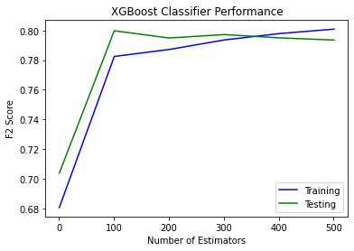

```python
plt.plot(n_est_vals, f2_trn_scores, color='blue', label='Training')
plt.plot(n_est_vals, f2_tst_scores, color='green', label='Testing')
plt.title('XGBoost Classifier Performance')
plt.xlabel('Number of Estimators')
plt.ylabel('F2 Score')
plt.legend()
plt.show()
```

## Logistic Regression Model

The first model that we tried on this dataset is “Logistic regression”. This model classifies and predicts the data based on the probabilities. We can use 0.5 as the threshold. This model did not give a satisfying accuracy on sampled and scaled dataset. Un-balanced dataset had high accuracy, but that dataset had a very few nonfunctional waterpoints.

### Logistic Regression with NO oversampling

```python
f2_scorer = make_scorer(fbeta_score, beta=2)
model = 'lr'
start = time.time()
train_metrics, test_metrics = fit_predict_eval_model(X_train, X_test, y_train, y_test,
                                 model=model, scoring=f2_scorer)

end = time.time()
elapsed = end - start
print(f'modeling took {elapsed} seconds')
print(f'*** training metrics for model={model} ***')
for metric, val in train_metrics.items():
    print(f'{metric}:\n {val}')

print(f'\n*** testing metrics for model={model} ***')
for metric, val in test_metrics.items():
    print(f'{metric}:\n {val}')
```

```
***** Fitting Model *****
***** Tuning Hyperparameters *****
{'C': 0.001, 'penalty': 'l1', 'solver': 'liblinear'}
***** Getting Logistic Regression Predictions *****
***** Getting Performance Metrics *****
modeling took 121.36825013160706 seconds
*** training metrics for model=lr ***
conf_mtx:
 [[    0 13992]
 [    0 60599]]
accuracy:
 0.8124170476330924
auc:
 0.5
recall:
 [0. 1.]
precision:
 [       nan 0.81241705]
f1_score:
 [       nan 0.89650122]
f2_score:
 [       nan 0.95585939]

*** testing metrics for model=lr ***
conf_mtx:
 [[    0  4810]
 [    0 20054]]
accuracy:
 0.8065476190476191
auc:
 0.5
recall:
 [0. 1.]
precision:
 [       nan 0.80654762]
f1_score:
 [       nan 0.89291598]
f2_score:
 [       nan 0.95422535]
```

### Logistic Regression with oversampling SMOTE

```python
f2_scorer = make_scorer(fbeta_score, beta=2)
model = 'lr'
start = time.time()
train_metrics, test_metrics = fit_predict_eval_model(X_train, X_test, y_train, y_test,
                                 model=model, scoring=f2_scorer, resample=True)

end = time.time()
elapsed = end - start
print(f'modeling took {elapsed} seconds')
print(f'*** training metrics for model={model} ***')
for metric, val in train_metrics.items():
    print(f'{metric}:\n {val}')

print(f'\n*** testing metrics for model={model} ***')
for metric, val in test_metrics.items():
    print(f'{metric}:\n {val}')
```

```
***** Oversampling Data *****
***** Fitting Model *****
***** Tuning Hyperparameters *****
{'C': 10, 'penalty': 'l2', 'solver': 'newton-cg'}
***** Getting Logistic Regression Predictions *****
***** Getting Performance Metrics *****
modeling took 275.6876530647278 seconds
*** training metrics for model=lr ***
conf_mtx:
 [[34414 26185]
 [11252 49347]]
accuracy:
 0.691108764171026
auc:
 0.691108764171026
recall:
 [0.56789716 0.81432037]
precision:
 [0.75360224 0.65332574]
f1_score:
 [0.6477015  0.72499284]
f2_score:
 [0.59733668 0.77607194]

*** testing metrics for model=lr ***
conf_mtx:
 [[ 1630  3180]
 [ 3772 16282]]
accuracy:
 0.7203989703989704
auc:
 0.5753925938427783
recall:
 [0.33887734 0.81190785]
precision:
 [0.3017401  0.83660467]
f1_score:
 [0.31923228 0.82407126]
f2_score:
 [0.33073614 0.81672987]
```

## KNN model

KNN model can also be used for both classification and regression predictive problems. However, it is more widely used in classification problems in the industry. KNN output is easy to interpret.

KNN accuracy is good in our dataset but other matrices are not compred to XGboost or Random forest. KNN took longer to run. It took **106 mins** to run the model with the available dataset.

### KNN with NO oversampling

```python
f2_scorer = make_scorer(fbeta_score, beta=2)
model = 'knn'
start = time.time()
train_metrics, test_metrics = fit_predict_eval_model(X_train, X_test, y_train, y_test,
                                 model=model, scoring=f2_scorer)

end = time.time()
elapsed = end - start
print(f'modeling took {elapsed} seconds')
print(f'*** training metrics for model={model} ***')
for metric, val in train_metrics.items():
    print(f'{metric}:\n {val}')

print(f'\n*** testing metrics for model={model} ***')
for metric, val in test_metrics.items():
    print(f'{metric}:\n {val}')
```

```
***** Fitting Model *****
***** Tuning Hyperparameters *****
***** Getting KNN Predictions *****
***** Getting Performance Metrics *****
modeling took 2128.0721757411957 seconds
*** training metrics for model=knn ***
conf_mtx:
 [[ 1151 12841]
 [ 1006 59593]]
accuracy:
 0.8143609818878953
auc:
 0.5328301790790703
recall:
 [0.08226129 0.98339907]
precision:
 [0.5336115  0.82272137]
f1_score:
 [0.14254753 0.89591304]
f2_score:
 [0.09901075 0.94643141]

*** testing metrics for model=knn ***
conf_mtx:
 [[  304  4506]
 [  438 19616]]
accuracy:
 0.8011583011583011
auc:
 0.5206803169902801
recall:
 [0.06320166 0.97815897]
precision:
 [0.4097035  0.81319957]
f1_score:
 [0.10951009 0.88808403]
f2_score:
 [0.07606846 0.94002185]
```

### KNN with oversampling SMOTE

```python
f2_scorer = make_scorer(fbeta_score, beta=2)
model = 'knn'
start = time.time()
train_metrics, test_metrics = fit_predict_eval_model(X_train, X_test, y_train, y_test,
                                 model=model, scoring=f2_scorer, resample=True)

end = time.time()
elapsed = end - start
print(f'modeling took {elapsed} seconds')
print(f'*** training metrics for model={model} ***')
for metric, val in train_metrics.items():
    print(f'{metric}:\n {val}')

print(f'\n*** testing metrics for model={model} ***')
for metric, val in test_metrics.items():
    print(f'{metric}:\n {val}')
```

```
***** Oversampling Data *****
***** Fitting Model *****
***** Tuning Hyperparameters *****
***** Getting KNN Predictions *****
***** Getting Performance Metrics *****
modeling took 6369.765440940857 seconds
*** training metrics for model=knn ***
conf_mtx:
 [[49511 11088]
 [11193 49406]]
accuracy:
 0.8161603326787571
auc:
 0.8161603326787571
recall:
 [0.81702668 0.81529398]
precision:
 [0.81561347 0.8167091 ]
f1_score:
 [0.81631946 0.81600092]
f2_score:
 [0.81674365 0.81557661]

*** testing metrics for model=knn ***
conf_mtx:
 [[ 2433  2377]
 [ 6710 13344]]
accuracy:
 0.6345318532818532
auc:
 0.5856123083060352
recall:
 [0.50582121 0.66540341]
precision:
 [0.26610522 0.84880097]
f1_score:
 [0.34874221 0.74599581]
f2_score:
 [0.42860163 0.69545639]
```

## Naive Bayes model

Naive Bayes is a kind of classifier which uses the Bayes Theorem. It predicts membership probabilities for each class such as the probability that given record or data point belongs to a particular class. The class with the highest probability is considered as the most likely class.

This model was the fastest to run but didnot performed good when we considered Recall, precision and F1 and F2 scores.

### Naives Bayes with NO oversampling

```python
f2_scorer = make_scorer(fbeta_score, beta=2)
model = 'nb'
start = time.time()
train_metrics, test_metrics = fit_predict_eval_model(X_train, X_test, y_train, y_test,
                                 model=model, scoring=f2_scorer)

end = time.time()
elapsed = end - start
print(f'modeling took {elapsed} seconds')
print(f'*** training metrics for model={model} ***')
for metric, val in train_metrics.items():
    print(f'{metric}:\n {val}')

print(f'\n*** testing metrics for model={model} ***')
for metric, val in test_metrics.items():
    print(f'{metric}:\n {val}')
```

```
***** Fitting Model *****
***** Tuning Hyperparameters *****
***** Getting Naive Bayes Predictions *****
***** Getting Performance Metrics *****
modeling took 3.14005184173584 seconds
*** training metrics for model=nb ***
conf_mtx:
 [[  416 13576]
 [ 1086 59513]]
accuracy:
 0.8034347307315896
auc:
 0.5059050936037821
recall:
 [0.02973128 0.98207891]
precision:
 [0.27696405 0.81425385]
f1_score:
 [0.05369821 0.89032673]
f2_score:
 [0.0361928  0.94319857]

*** testing metrics for model=nb ***
conf_mtx:
 [[  142  4668]
 [  355 19699]]
accuracy:
 0.7979810167310167
auc:
 0.5059098127363809
recall:
 [0.02952183 0.9822978 ]
precision:
 [0.28571429 0.80842943]
f1_score:
 [0.05351423 0.88692285]
f2_score:
 [0.03597305 0.94178786]
```

### Naives Bayes with oversampling SMOTE

```python
f2_scorer = make_scorer(fbeta_score, beta=2)
model = 'nb'
start = time.time()
train_metrics, test_metrics = fit_predict_eval_model(X_train, X_test, y_train, y_test,
                                 model=model, scoring=f2_scorer, resample=True)

end = time.time()
elapsed = end - start
print(f'modeling took {elapsed} seconds')
print(f'*** training metrics for model={model} ***')
for metric, val in train_metrics.items():
    print(f'{metric}:\n {val}')

print(f'\n*** testing metrics for model={model} ***')
for metric, val in test_metrics.items():
    print(f'{metric}:\n {val}')
```

```
***** Oversampling Data *****
***** Fitting Model *****
***** Tuning Hyperparameters *****
***** Getting Naive Bayes Predictions *****
***** Getting Performance Metrics *****
modeling took 6.82506799697876 seconds
*** training metrics for model=nb ***
conf_mtx:
 [[53856  6743]
 [38462 22137]]
accuracy:
 0.6270152972821333
auc:
 0.6270152972821333
recall:
 [0.88872754 0.36530306]
precision:
 [0.58337486 0.76651662]
f1_score:
 [0.70438212 0.49479766]
f2_score:
 [0.80450773 0.40801619]

*** testing metrics for model=nb ***
conf_mtx:
 [[ 3992   818]
 [12745  7309]]
accuracy:
 0.4545125482625483
auc:
 0.5972017859471734
recall:
 [0.82993763 0.36446594]
precision:
 [0.23851347 0.89934785]
f1_score:
 [0.37053882 0.51871829]
f2_score:
 [0.5547989  0.41367171]
```

## Random Forest Model

Random forest is a supervised learning algorithm. The "forest" of decision trees is built usually trained with the “bagging” method. The general idea of the bagging method is that a combination of learning models increases the overall result.

In random forests, there is no need for cross-validation or a separate test set to get an unbiased estimate of the test set error. It is estimated internally, during the run. Each tree is constructed using a different bootstrap sample from the original data. About one-third of the cases are left out of the bootstrap sample and not used in the construction of the kth tree.

We see that it performed as good as as XGboost but took longer to complete. It took 520 mins where XGboost took only 46 mins.

### Random Forest with NO oversampling

```python
f2_scorer = make_scorer(fbeta_score, beta=2)
model = 'rf'
start = time.time()
train_metrics, test_metrics = fit_predict_eval_model(X_train, X_test, y_train, y_test,
                                 model=model, scoring=f2_scorer)

end = time.time()
elapsed = end - start
print(f'modeling took {elapsed} seconds')
print(f'*** training metrics for model={model} ***')
for metric, val in train_metrics.items():
    print(f'{metric}:\n {val}')

print(f'\n*** testing metrics for model={model} ***')
for metric, val in test_metrics.items():
    print(f'{metric}:\n {val}')
```

```
***** Fitting Model *****
***** Tuning Hyperparameters *****
***** Getting Random Forest Predictions *****
***** Getting Performance Metrics *****
modeling took 17906.895539999008 seconds
*** training metrics for model=rf ***
conf_mtx:
 [[   35 13957]
 [    4 60595]]
accuracy:
 0.8128326473703262
auc:
 0.501217710849163
recall:
 [0.00250143 0.99993399]
precision:
 [0.8974359  0.81278839]
f1_score:
 [0.00498895 0.89670073]
f2_score:
 [0.00312461 0.9559139 ]

*** testing metrics for model=rf ***
conf_mtx:
 [[   12  4798]
 [    1 20053]]
accuracy:
 0.8069900257400258
auc:
 0.501222468565642
recall:
 [0.0024948  0.99995013]
precision:
 [0.92307692 0.8069293 ]
f1_score:
 [0.00497616 0.89312994]
f2_score:
 [0.0031164  0.95429583]
```

### Random Forest with oversampling SMOTE

```python
f2_scorer = make_scorer(fbeta_score, beta=2)
model = 'rf'
start = time.time()
train_metrics, test_metrics = fit_predict_eval_model(X_train, X_test, y_train, y_test,
                                 model=model, scoring=f2_scorer, resample=True)

end = time.time()
elapsed = end - start
print(f'modeling took {elapsed} seconds')
print(f'*** training metrics for model={model} ***')
for metric, val in train_metrics.items():
    print(f'{metric}:\n {val}')

print(f'\n*** testing metrics for model={model} ***')
for metric, val in test_metrics.items():
    print(f'{metric}:\n {val}')
```

```
***** Oversampling Data *****
***** Fitting Model *****
***** Tuning Hyperparameters *****
***** Getting Random Forest Predictions *****
***** Getting Performance Metrics *****
modeling took 31224.12748336792 seconds
*** training metrics for model=rf ***
conf_mtx:
 [[45355 15244]
 [10753 49846]]
accuracy:
 0.7854997607221241
auc:
 0.7854997607221241
recall:
 [0.74844469 0.82255483]
precision:
 [0.80835175 0.7658012 ]
f1_score:
 [0.77724558 0.79316408]
f2_score:
 [0.75970506 0.81054097]

*** testing metrics for model=rf ***
conf_mtx:
 [[ 1906  2904]
 [ 4148 15906]]
accuracy:
 0.7163770913770914
auc:
 0.594708134191529
recall:
 [0.3962578  0.79315847]
precision:
 [0.31483317 0.84561404]
f1_score:
 [0.35088365 0.81854673]
f2_score:
 [0.37676919 0.80312241]
```

### Visualize Confusion Matrix

```python
import seaborn as sns
import numpy as np
import matplotlib.pyplot as plt
def plotConfusionMatrix(model,cf_matrix):
    ax =   sns.heatmap(cf_matrix/np.sum(cf_matrix), annot=True,
            fmt='.2%', cmap='Blues')

    ax.set_title(model);
    ax.set_xlabel('\nPredicted Values')
    ax.set_ylabel('Actual Values ');

    ## Ticket labels - List must be in alphabetical order
    ax.xaxis.set_ticklabels(['Non Functional','Functional'])
    ax.yaxis.set_ticklabels(['Non Functional','Functional'])

    ## Display the visualization of the Confusion Matrix.
    plt.show()
```

# Matrix of Training Data (Oversampled)

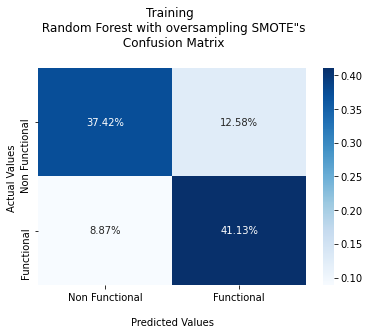

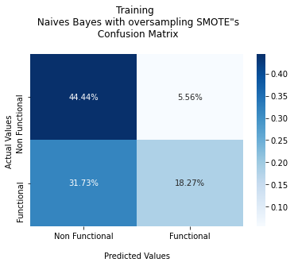

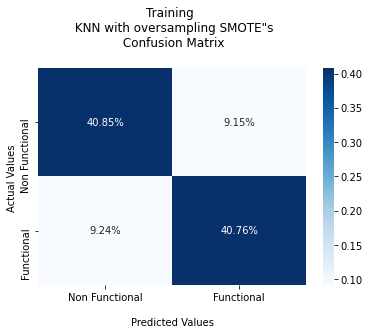

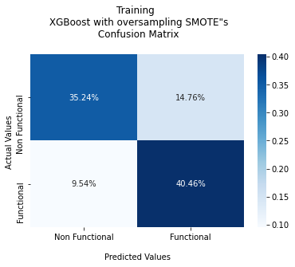

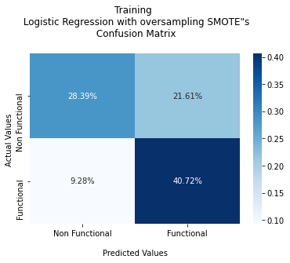

```python
cf_matrix =[[45355,15244],
 [10753 ,49846]]
norm = np.linalg.norm(cf_matrix)
cf_matrix = cf_matrix/norm
plotConfusionMatrix('Training \n Random Forest with oversampling SMOTE"s\n Confusion Matrix\n',cf_matrix)

cf_matrix =[[53856,  6743],
 [38462 ,22137]]
plotConfusionMatrix('Training \n Naives Bayes with oversampling SMOTE"s\n Confusion Matrix\n',cf_matrix)

cf_matrix =[[49511, 11088],
 [11193, 49406]]
plotConfusionMatrix('Training \n KNN with oversampling SMOTE"s\n Confusion Matrix\n',cf_matrix)

cf_matrix = [[42706, 17893],
 [11568,49031]]
plotConfusionMatrix('Training \n XGBoost with oversampling SMOTE"s\n Confusion Matrix\n',cf_matrix)

cf_matrix =[[34414,26185],
 [11252, 49347]]
plotConfusionMatrix('Training \n Logistic Regression with oversampling SMOTE"s\n Confusion Matrix\n',cf_matrix)
```

# Matrix of Testing Data

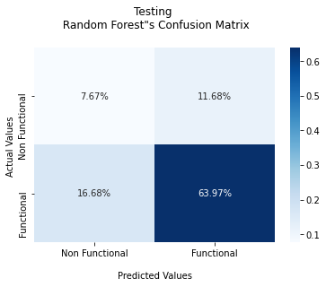

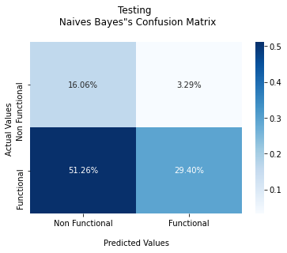

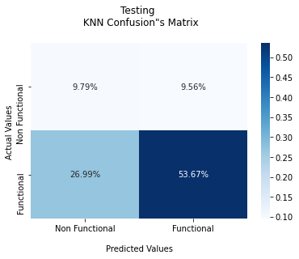

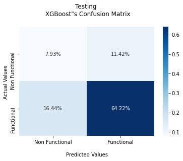

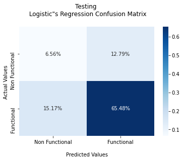

```python
cf_matrix =[[ 1906,  2904],
 [ 4148,15906]]
norm = np.linalg.norm(cf_matrix)
cf_matrix = cf_matrix/norm
plotConfusionMatrix('Testing \n Random Forest"s Confusion Matrix\n',cf_matrix)
cf_matrix =[[ 3992 ,  818],
 [12745 , 7309]]
plotConfusionMatrix('Testing \n Naives Bayes"s Confusion Matrix\n',cf_matrix)
cf_matrix =[[ 2433 , 2377],
 [ 6710, 13344]]
plotConfusionMatrix('Testing \n KNN Confusion"s Matrix\n',cf_matrix)
cf_matrix = [[ 1971 , 2839],
 [ 4087, 15967]]
plotConfusionMatrix('Testing \n XGBoost"s Confusion Matrix\n',cf_matrix)
cf_matrix =[[ 1630  ,3180],
 [ 3772 ,16282]]
plotConfusionMatrix('Testing \n Logistic"s Regression Confusion Matrix\n',cf_matrix)
```